# Exercises for Lecture 9: Binary regression (ii)

EBA3500 Data analysis with programming

Author

Jonas Moss

## 1 Maximum likelihood and univariate distributions

Recall that $\sqrt{n}(\hat{\theta} - \theta) \to N(0, I(\theta)^{-1})$, where $I(\theta)$ is the Fisher information. When $\theta$ is a scalar, you can use this information to construct confidence intervals for $\theta$ using the $Z$-interval construction. A $(1-\alpha)\%$ confidence interval for $\theta$ is
$$CI(\theta; 1-\alpha) = [\hat{\theta} - \Phi^{-1}(1-\alpha/2)I(\theta)^{-1}/\sqrt{n}, \hat{\theta} + \Phi^{-1}(1-\alpha/2)I(\theta)^{-1}/\sqrt{n}],$$
where $\Phi^{-1}$ is the quantile function of the normal distribution, called `ppf` in Scipy. Recall that
$$\Phi^{-1}(1-\alpha/2)\approx 1.96$$
when $\alpha = 0.95$ and
$$\Phi^{-1}(1-\alpha/2)\approx 1.64$$
when $\alpha = 0.90$.

### 1.1 Poisson distribution

Let $f(x;\lambda)=\frac{\lambda^{k}e^{-\lambda}}{k!}$ be the pmf of a Poisson distribution with parametert $\lambda$. The Poisson distribution is used to event counts when the probability of an event happening is very small but there are many occasions where an event can happen. It is used, e.g., for modeling the number of insurance claims.

> 1. Plot the Poisson pmf for $\lambda=1,4,10$.

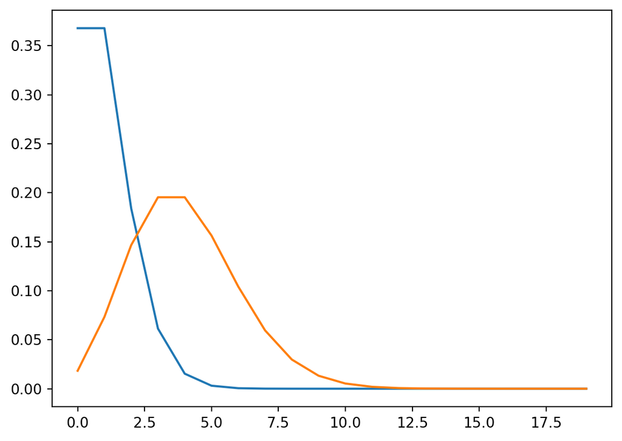

```python
from scipy.stats import poisson
import numpy as np
import matplotlib.pyplot as plt
x = np.arange(0, 20)
plt.plot(x, poisson.pmf(x, 1))
plt.plot(x, poisson.pmf(x, 4))
```

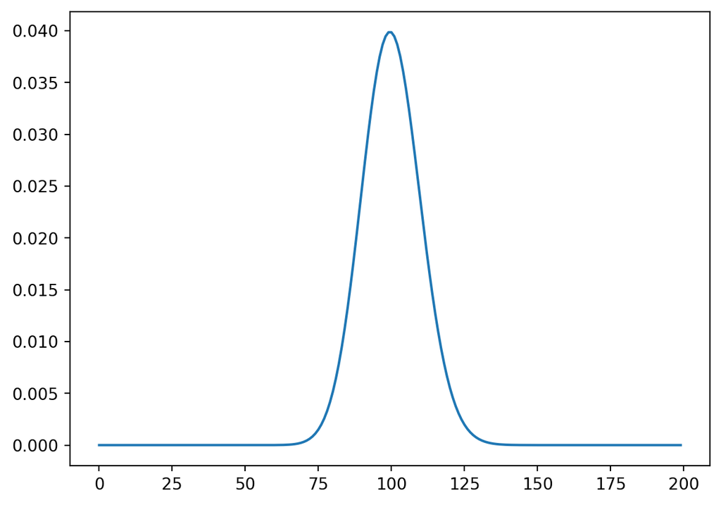

```python
x = np.arange(0, 200)
plt.plot(x, poisson.pmf(x, 100))
```

> 2. Calculate the maximum likelihood estimator of $\lambda$.

$$\begin{eqnarray*}
\log\left[\prod_{i=1}^{n}\frac{\lambda^{k}e^{-\lambda}}{k!}\right] & = & \sum_{i=1}^{n}\log\left[\frac{\lambda^{x_{i}}e^{-\lambda}}{k!}\right]\\
& = & \sum_{i=1}^{n}x_{i}\log\left[\lambda\right]-\lambda-\log x_{i}!
\end{eqnarray*}$$
Take the derivative with respect to $\lambda$:
$$\frac{d}{d\lambda}\log\left[\prod_{i=1}^{n}\frac{\lambda^{k}e^{-\lambda}}{k!}\right]=\frac{1}{\lambda}\sum_{i=1}^{n}x_{i}-n$$
set this equal to $0$ to find
$$\hat{\lambda}=\overline{x}.$$

> 3. Calculate the mean and variance of $X$ when $X$ is Poisson distributed with parameter $\lambda$.

To solve this one, use the following trick. First differentiate inside and outside the sum, as follows.
$$\frac{d}{d\lambda}\sum_{k=0}^{\infty}\frac{\lambda^{k}e^{-\lambda}}{k!}=\sum_{k=0}^{\infty}\frac{d}{d\lambda}\frac{\lambda^{k}e^{-\lambda}}{k!}$$
Then, observe that $\frac{d}{d\lambda}\sum_{k=0}^{\infty}\frac{\lambda^{k}e^{-\lambda}}{k!} = 0$ and use the fact that $\frac{d\lambda^{k}e^{-\lambda}}{d\lambda}=k\lambda^{k-1}e^{-\lambda}-\lambda e^{-\lambda}\lambda^{k}$ to conclude that and $k/k!=1/(k-1)!$ to conclude that

$$\sum_{k=0}^{\infty}\frac{k\lambda^{k-1}e^{-\lambda}}{k!}=\sum_{k=0}^{\infty}\frac{\lambda^{k}e^{-\lambda}}{k!}=1$$

Now multiply both sides by $\lambda$, so that
$$\sum_{k=0}^{\infty}\frac{k\lambda^{k}e^{-\lambda}}{k!}=\lambda.$$
But the left-hand side equals the expectation of the Poisson!

The variance can be calculated in the same way; the result is $\lambda$.

> 4. Calculate the Fisher information of $\lambda$.

See e.g. [this document](https://ani.stat.fsu.edu/~debdeep/Fisher.pdf) for a solution. (Search the document for “Poisson”). The Fisher information is $1/\lambda$.

> 5. Use the asymptotic theory of maximum likelihood estimation to derive a confidence interval for $\lambda$.

Just plug in $\overline{x}$ for $\hat{\theta}$ and $\overline{x}$ for the inverse Fisher information.

> 6. Using the [annual fatal car crash data](https://www.statista.com/statistics/437961/number-of-road-deaths-in-norway/), estimate $\lambda$ and calculate a $95\%$ confidence interval for $\lambda$.

```python
crashes = [242, 233, 255, 212, 208, 168, 145, 187, 147, 117, 135, 106, 108, 108, 93]
```

Let’s make a `CI` function:

```python
def ci(x):
  """95% CI for the Poisson distribution parameter."""
  n = len(x)
  theta = np.mean(x)
  fisher_inv = np.mean(x)
  return [theta - 1.96 * fisher_inv / np.sqrt(n), theta + 1.96 * fisher_inv / np.sqrt(n)]
```

And calculate the CI using it.

```python
ci(crashes)
```

```
[81.13626359329803, 247.39706974003533]
```

> 7. Do you think using a Poisson distribution is reasonable for this data? (*Hint:* Try to simulate from the Poisson distribution with the estimated parameters and see what it looks like; compare to the graph on the linked site.)

I’ll solve it in a different way. The variance and mean of the Poisson are supposed to be equal. But in this dataset we have

```python
np.mean(crashes)
```

```
164.26666666666668
```

and

```python
np.var(crashes)
```

```
2819.1288888888885
```

And it seems very unlikely that these numbers are the same in the population!

This phenomenon, when the variance is greater than the mean in count data, is called *overdispersion*. The go-to model for such situations is the [negative binomial distribution](https://en.wikipedia.org/wiki/Negative_binomial_distribution).

## 2 Logistic regression modelling

### 2.1 Endometrial data

Load the endometrial data, available at the Github rep under the “resources folder.

```python
import pyreadr
endometrial = pyreadr.read_r("endometrial.Rda")["endometrial"]
```

> 1. Run a logistic regression with `"HG ~ NV + PI + EH"`. What happens with with the coefficient for `NV`?

```python
import pyreadr
import pandas as pd
import numpy as np
import statsmodels.formula.api as smf
import statsmodels.api as sm
endometrial = pyreadr.read_r("endometrial.Rda")["endometrial"]
mod = smf.logit("HG ~ NV + PI + EH", data = endometrial).fit()
mod.summary()
```

Logit Regression Results

| Dep. Variable: | HG | No. Observations: | 79 |
| --- | --- | --- | --- |
| Model: | Logit | Df Residuals: | 75 |
| Method: | MLE | Df Model: | 3 |
| Date: | Sat, 05 Nov 2022 | Pseudo R-squ.: | 0.4720 |
| Time: | 13:39:29 | Log-Likelihood: | -27.697 |
| converged: | False | LL-Null: | -52.451 |
| Covariance Type: | nonrobust | LLR p-value: | 1.016e-10 |

|  | coef | std err | z | P>\|z\| | [0.025 | 0.975] |
| --- | --- | --- | --- | --- | --- | --- |
| Intercept | 4.3045 | 1.637 | 2.629 | 0.009 | 1.095 | 7.514 |
| NV | 19.5002 | 5458.415 | 0.004 | 0.997 | -1.07e+04 | 1.07e+04 |
| PI | -0.0422 | 0.044 | -0.952 | 0.341 | -0.129 | 0.045 |
| EH | -2.9026 | 0.846 | -3.433 | 0.001 | -4.560 | -1.245 |

Possibly complete quasi-separation: A fraction 0.16 of observations can be  
perfectly predicted. This might indicate that there is complete  
quasi-separation. In this case some parameters will not be identified.

The `NV` coefficient has a huge standard error, suggesting problems with perfect separation! > 2. Look at the outcome `HG` when `NV=1`. What do you see? What effects does this have on the maximum likelihood estimate of `NV`?

```python
X = pd.concat([
  pd.Series(np.ones(endometrial.shape[0]), dtype = "int").rename('Intercept'),
  endometrial], axis=1)
X.query("NV == 1")
```

|  | Intercept | NV | PI | EH | HG |
| --- | --- | --- | --- | --- | --- |
| 21 | 1 | 1 | 38 | 0.97 | 1 |
| 22 | 1 | 1 | 22 | 1.14 | 1 |
| 23 | 1 | 1 | 7 | 0.88 | 1 |
| 24 | 1 | 1 | 25 | 0.91 | 1 |
| 25 | 1 | 1 | 15 | 0.58 | 1 |
| 47 | 1 | 1 | 22 | 1.44 | 1 |
| 48 | 1 | 1 | 40 | 1.18 | 1 |
| 49 | 1 | 1 | 5 | 0.93 | 1 |
| 50 | 1 | 1 | 0 | 1.17 | 1 |
| 70 | 1 | 1 | 49 | 0.27 | 1 |
| 74 | 1 | 1 | 11 | 1.01 | 1 |
| 75 | 1 | 1 | 21 | 0.98 | 1 |
| 77 | 1 | 1 | 19 | 1.02 | 1 |

The vaue of `HG=1` for every single `NV=1`! Thus its “beneficial” to push the coefficient of `NV` has high as possible - its ML estimator is equal to $\infty$.

3. Modify the data frame `endometrial` to make the problem go away. I’m taking a random element where `NV=1` and just change it to $0$. (This is not recommended - but it works.)

```python
endometrial.at[77, "HG"]
```

```
1
```

And we change it.

```python
endometrial.at[77, "HG"] = 0
mod = smf.logit("HG ~ NV + PI + EH", data = endometrial).fit()
mod.summary()
```

```
Optimization terminated successfully.
         Current function value: 0.397682
         Iterations 7
```

Logit Regression Results

| Dep. Variable: | HG | No. Observations: | 79 |
| --- | --- | --- | --- |
| Model: | Logit | Df Residuals: | 75 |
| Method: | MLE | Df Model: | 3 |
| Date: | Sat, 05 Nov 2022 | Pseudo R-squ.: | 0.3951 |
| Time: | 13:39:30 | Log-Likelihood: | -31.417 |
| converged: | True | LL-Null: | -51.934 |
| Covariance Type: | nonrobust | LLR p-value: | 6.433e-09 |

|  | coef | std err | z | P>\|z\| | [0.025 | 0.975] |
| --- | --- | --- | --- | --- | --- | --- |
| Intercept | 3.9708 | 1.498 | 2.650 | 0.008 | 1.034 | 6.908 |
| NV | 2.1035 | 1.179 | 1.785 | 0.074 | -0.207 | 4.414 |
| PI | -0.0314 | 0.038 | -0.820 | 0.412 | -0.106 | 0.044 |
| EH | -2.8001 | 0.809 | -3.462 | 0.001 | -4.386 | -1.215 |